# Lab04: Artificial Neural Networks and Support Vector Machines

Yalin Yang

2021-05-05

```r
library(ggplot2);library(e1071); library(ISLR) ;library(gmodels); library(ROCR);
library(caret);library(parallel)
library(AmesHousing); library(rsample);library(recipes)
cl <- parallel::makeCluster(detectCores())
```

# 1 Part 1: Support Vector Machines [15 points]

## 1.1 Task 1: You will answer an applied exercise in James et al., 2013. `An Introduction to Statistical Learning with Application in R`. Please follow the sequence of tasks/questions in the exercises. `Answer the questions (a) to (i) of exercise 5 on pages 369-370`. Show your code. [5 point]

We have seen that we can fit an SVM with a non-linear kernel in order to perform classification using a non-linear decision boundary.We will now see that we can also obtain a non-linear decision boundary by performing logistic regression using non-linear transformations of the features.

### 1.1.1 a

Generate a data set with `n = 500` and `p = 2`, such that the observations belong to two classes with a quadratic decision boundary between them.

```r
set.seed(100)
x1 <- runif(500) - 0.5
x2 <- runif(500) - 0.5
y <-  1*( x1^2-x2^2 > 0)
```

### 1.1.2 b

Plot the observations, colored according to their class labels. Your plot should display `X1` on the x-`axis`, and `X2` on the `yaxis.`

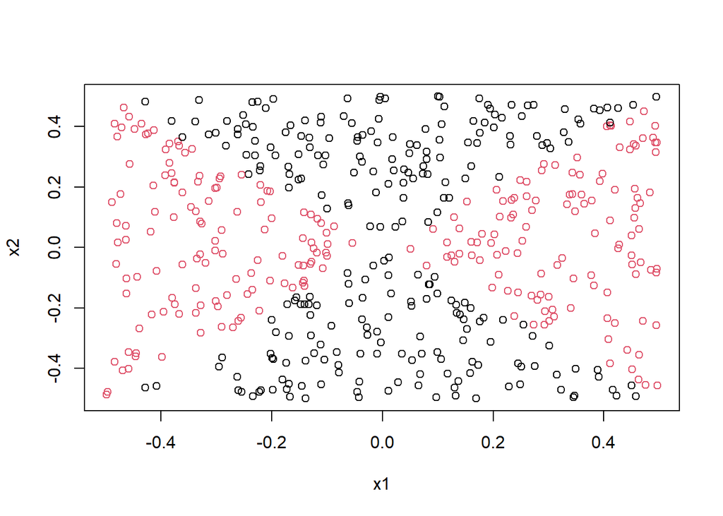

```r
plot(x1,x2,col = as.factor(y))
```

### 1.1.3 c

Fit a logistic regression model to the data, using `X1` and `X2` as predictors.

```r
set.seed(1)
df <- data.frame(x1 = x1,x2 = x2, y = as.factor(y))
index <- caret::createDataPartition(df$y, p = 0.7, list = FALSE)
df_train <- df[index, ]
df_test  <- df[-index, ]
```

```r
logistic.mod1 <- glm(y ~ ., family = binomial(link="logit"), data = df_train)
summary(logistic.mod1)
```

```
##
## Call:
## glm(formula = y ~ ., family = binomial(link = "logit"), data = df_train)
##
## Deviance Residuals:
##    Min      1Q  Median      3Q     Max
## -1.208  -1.156  -1.114   1.191   1.252
##
## Coefficients:
##             Estimate Std. Error z value Pr(>|z|)
## (Intercept) -0.04856    0.10712  -0.453    0.650
## x1          -0.16863    0.38301  -0.440    0.660
## x2          -0.10118    0.36030  -0.281    0.779
##
## (Dispersion parameter for binomial family taken to be 1)
##
##     Null deviance: 486.36  on 350  degrees of freedom
## Residual deviance: 486.08  on 348  degrees of freedom
## AIC: 492.08
##
## Number of Fisher Scoring iterations: 3
```

```r
logistic_as_factor <- function(result){
  return(as.factor(ifelse(result > 0.5,1,0)))
}
logistic.pred <- predict(logistic.mod1,newdata = df_test,type = "response")
logistic.pred <- logistic_as_factor(logistic.pred)
confusionMatrix(logistic.pred,df_test$y)
```

```
## Confusion Matrix and Statistics
##
##           Reference
## Prediction  0  1
##          0 65 59
##          1 12 13
##
##                Accuracy : 0.5235
##                  95% CI : (0.4402, 0.6059)
##     No Information Rate : 0.5168
##     P-Value [Acc > NIR] : 0.4677
##
##                   Kappa : 0.0252
##
##  Mcnemar's Test P-Value : 4.783e-08
##
##             Sensitivity : 0.8442
##             Specificity : 0.1806
##          Pos Pred Value : 0.5242
##          Neg Pred Value : 0.5200
##              Prevalence : 0.5168
##          Detection Rate : 0.4362
##    Detection Prevalence : 0.8322
##       Balanced Accuracy : 0.5124
##
##        'Positive' Class : 0
##
```

### 1.1.4 d

Apply this model to the `training data` in order to obtain a predicted class label for each training observation. Plot the observations, colored according to the predicted class labels. The decision boundary should be linear.

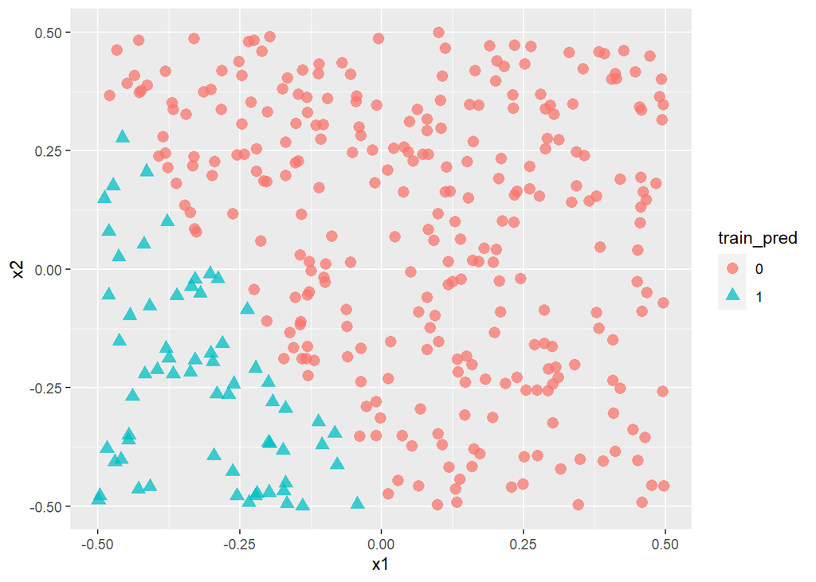

```r
train_pred <- fitted(logistic.mod1)
train_pred <- logistic_as_factor(train_pred)
ggplot(df_train, aes(x = x1, y = x2)) +
  geom_point(aes(shape = train_pred, color = train_pred), size = 3, alpha = 0.75)
```

### 1.1.5 e

Now fit a logistic regression model to the data using non-linear functions of `X1` and `X2` as predictors (e.g. $X_1^2 , X_1×X_2, log(X_2)$,and so forth).

```r
x1_quad <- df_train$x1^2
x2_quad <- df_train$x2^2
x1.x2 <- df_train$x1 * df_train$x2
logistic.mod2 <- glm(y ~ . + x1_quad + x1.x2 + x2_quad, family = binomial(link="logit"), data = df_train)
summary(logistic.mod2)
```

```
##
## Call:
## glm(formula = y ~ . + x1_quad + x1.x2 + x2_quad, family = binomial(link = "logit"),
##     data = df_train)
##
## Deviance Residuals:
##        Min          1Q      Median          3Q         Max
## -1.297e-03  -2.000e-08  -2.000e-08   2.000e-08   1.274e-03
##
## Coefficients:
##              Estimate Std. Error z value Pr(>|z|)
## (Intercept)    -15.86     877.91  -0.018    0.986
## x1              80.73   57258.45   0.001    0.999
## x2              29.76   58845.81   0.001    1.000
## x1_quad      21017.33  673066.56   0.031    0.975
## x1.x2           67.38  125797.92   0.001    1.000
## x2_quad     -21116.18  703802.05  -0.030    0.976
##
## (Dispersion parameter for binomial family taken to be 1)
##
##     Null deviance: 4.8636e+02  on 350  degrees of freedom
## Residual deviance: 3.6068e-06  on 345  degrees of freedom
## AIC: 12
##
## Number of Fisher Scoring iterations: 25
```

```r
df_test$x1_quad <- df_test$x1^2
df_test$x1.x2 <- df_test$x1 * df_test$x2
df_test$x2_quad <- df_test$x2^2
logistic.pred <- predict(logistic.mod2,newdata = df_test,type = "response")
logistic.pred <- logistic_as_factor(logistic.pred)
confusionMatrix(logistic.pred,df_test$y)
```

```
## Confusion Matrix and Statistics
##
##           Reference
## Prediction  0  1
##          0 77  0
##          1  0 72
##
##                Accuracy : 1
##                  95% CI : (0.9755, 1)
##     No Information Rate : 0.5168
##     P-Value [Acc > NIR] : < 2.2e-16
##
##                   Kappa : 1
##
##  Mcnemar's Test P-Value : NA
##
##             Sensitivity : 1.0000
##             Specificity : 1.0000
##          Pos Pred Value : 1.0000
##          Neg Pred Value : 1.0000
##              Prevalence : 0.5168
##          Detection Rate : 0.5168
##    Detection Prevalence : 0.5168
##       Balanced Accuracy : 1.0000
##
##        'Positive' Class : 0
##
```

### 1.1.6 f

Apply this model to the training data in order to obtain a predicted class label for each training observation. Plot the observations, colored according to the predicted class labels. The decision boundary should be obviously non-linear. If it is not, then repeat (a)-(e) until you come up with an example in which the predicted class labels are obviously non-linear.

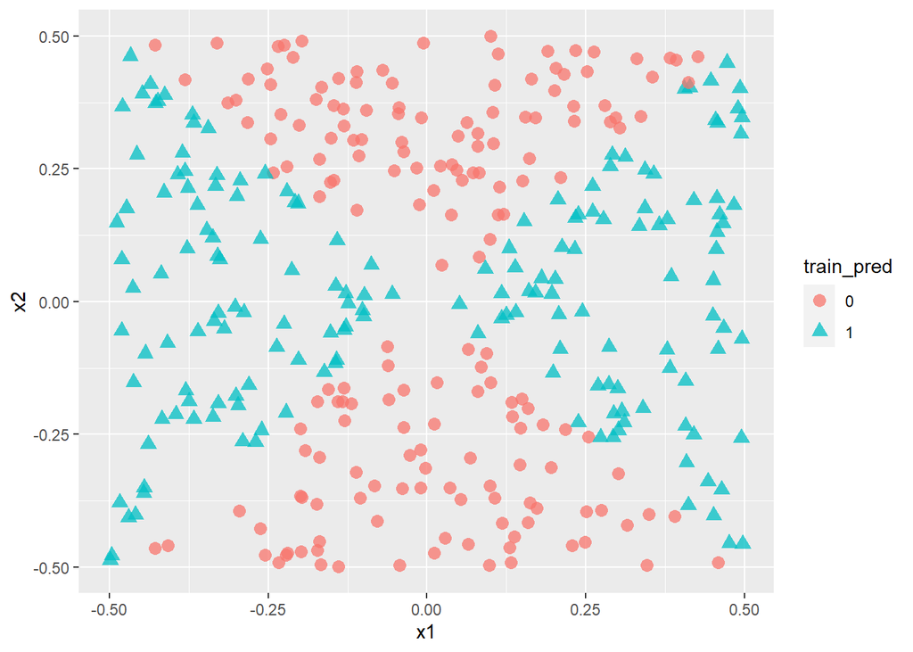

```r
train_pred <- fitted(logistic.mod2)
train_pred <- logistic_as_factor(train_pred)
ggplot(df_train, aes(x = x1, y = x2)) +
  geom_point(aes(shape = train_pred, color = train_pred), size = 3, alpha = 0.75)
```

### 1.1.7 g

Fit a support vector classifier to the data with `X1` and `X2` as predictors. Obtain a class prediction for each training observation. Plot the observations, colored according to the *predicted class labels*.

```r
set.seed(1)
tune.out <- tune(svm, y~.,data=df_train,kernel="linear",ranges=list(cost=c(0.001, 0.01, 0.1, 1,5,10,100)))
summary(tune.out)
```

```
##
## Parameter tuning of 'svm':
##
## - sampling method: 10-fold cross validation
##
## - best parameters:
##  cost
##   0.1
##
## - best performance: 0.4955556
##
## - Detailed performance results:
##    cost     error dispersion
## 1 1e-03 0.5041270 0.05538750
## 2 1e-02 0.5041270 0.05538750
## 3 1e-01 0.4955556 0.08069364
## 4 1e+00 0.5098413 0.04934440
## 5 5e+00 0.5184127 0.05028515
## 6 1e+01 0.5184127 0.05028515
## 7 1e+02 0.5184127 0.05028515
```

```r
bestmod <- tune.out$best.model
summary(bestmod)
```

```
##
## Call:
## best.tune(method = svm, train.x = y ~ ., data = df_train, ranges = list(cost = c(0.001,
##     0.01, 0.1, 1, 5, 10, 100)), kernel = "linear")
##
##
## Parameters:
##    SVM-Type:  C-classification
##  SVM-Kernel:  linear
##        cost:  0.1
##
## Number of Support Vectors:  345
##
##  ( 174 171 )
##
##
## Number of Classes:  2
##
## Levels:
##  0 1
```

```r
ypred <- predict(bestmod, df_test)
confusionMatrix(ypred, df_test$y)
```

```
## Confusion Matrix and Statistics
##
##           Reference
## Prediction  0  1
##          0 77 72
##          1  0  0
##
##                Accuracy : 0.5168
##                  95% CI : (0.4336, 0.5993)
##     No Information Rate : 0.5168
##     P-Value [Acc > NIR] : 0.533
##
##                   Kappa : 0
##
##  Mcnemar's Test P-Value : <2e-16
##
##             Sensitivity : 1.0000
##             Specificity : 0.0000
##          Pos Pred Value : 0.5168
##          Neg Pred Value :    NaN
##              Prevalence : 0.5168
##          Detection Rate : 0.5168
##    Detection Prevalence : 1.0000
##       Balanced Accuracy : 0.5000
##
##        'Positive' Class : 0
##
```

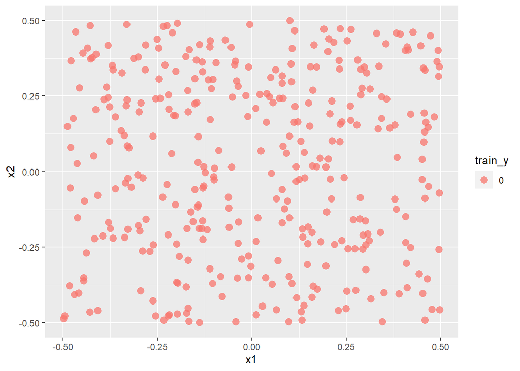

```r
train_y <- fitted(bestmod)
ggplot(df_train, aes(x = x1, y = x2)) +
  geom_point(aes(shape = train_y, color = train_y), size = 3, alpha = 0.75)
```

### 1.1.8 h

Fit a SVM using a non-linear kernel to the data. Obtain a class prediction for each training observation. Plot the observations, colored according to the predicted class labels.

```r
set.seed(1)
tune.out <- tune(svm, y~., data=df_train, kernel="radial",
                 ranges=list(cost=c(0.1,1,10,100,1000),gamma=c(0.5,1,2,3,4)))
summary(tune.out$best.model)
```

```
##
## Call:
## best.tune(method = svm, train.x = y ~ ., data = df_train, ranges = list(cost = c(0.1,
##     1, 10, 100, 1000), gamma = c(0.5, 1, 2, 3, 4)), kernel = "radial")
##
##
## Parameters:
##    SVM-Type:  C-classification
##  SVM-Kernel:  radial
##        cost:  100
##
## Number of Support Vectors:  37
##
##  ( 17 20 )
##
##
## Number of Classes:  2
##
## Levels:
##  0 1
```

```r
ypred <- predict(tune.out$best.model, df_test)
confusionMatrix(ypred, df_test$y)
```

```
## Confusion Matrix and Statistics
##
##           Reference
## Prediction  0  1
##          0 75  0
##          1  2 72
##
##                Accuracy : 0.9866
##                  95% CI : (0.9524, 0.9984)
##     No Information Rate : 0.5168
##     P-Value [Acc > NIR] : <2e-16
##
##                   Kappa : 0.9731
##
##  Mcnemar's Test P-Value : 0.4795
##
##             Sensitivity : 0.9740
##             Specificity : 1.0000
##          Pos Pred Value : 1.0000
##          Neg Pred Value : 0.9730
##              Prevalence : 0.5168
##          Detection Rate : 0.5034
##    Detection Prevalence : 0.5034
##       Balanced Accuracy : 0.9870
##
##        'Positive' Class : 0
##
```

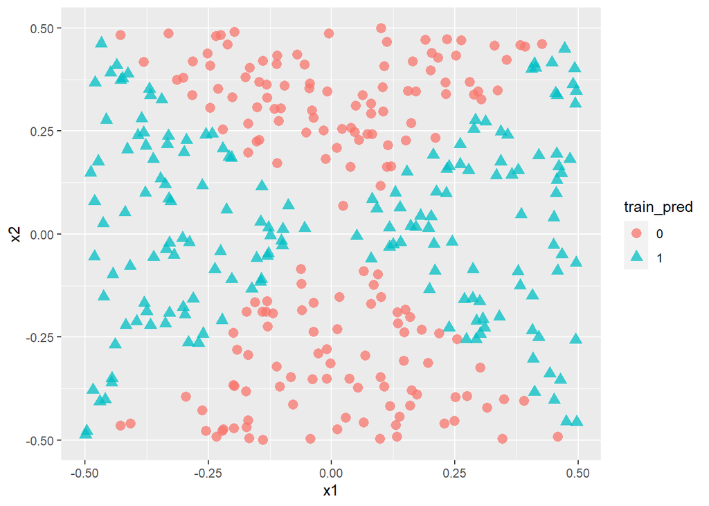

```r
train_pred <- fitted(tune.out$best.model)
ggplot(df_train, aes(x = x1, y = x2)) +
  geom_point(aes(shape = train_pred, color = train_pred), size = 3, alpha = 0.75)
```

### 1.1.9 i Comments

- `logistic regression` is not suitable for a very messy dataset. Although we could add quadratic terms or log terms to make the classifier boundary more reliable, it hard to figure out the logic behind(why and how it works).
- The performance of `SVM` is highly relying on the kernel function we choose. Therefore, we have to have a basic impression of our dataset and select the right classifier, which is hard when using high-dimensional datasets(not intuitive).

## 1.2 Task 2

For the following tasks continue working with the `credit.csv` data set to predict the default probabilities. Split the data into a stratified training data set with 70% of the observations and a test data set with the remaining 30% of the observations. Use **a radial kernel support vector classifier**. Identify with cross-evaluation the “optimal” cost parameter. Evaluate your optimal model with the confusion matrix for the test dataset and the `ROC` curve including the `AUC.` Show your code. [5 points]

```r
credit <- read.csv('credit.csv')
creditSplit <- initial_split(credit, breaks=7, prop=0.7, strata="default")
df_train <- training(creditSplit)
df_test <- testing(creditSplit)
```

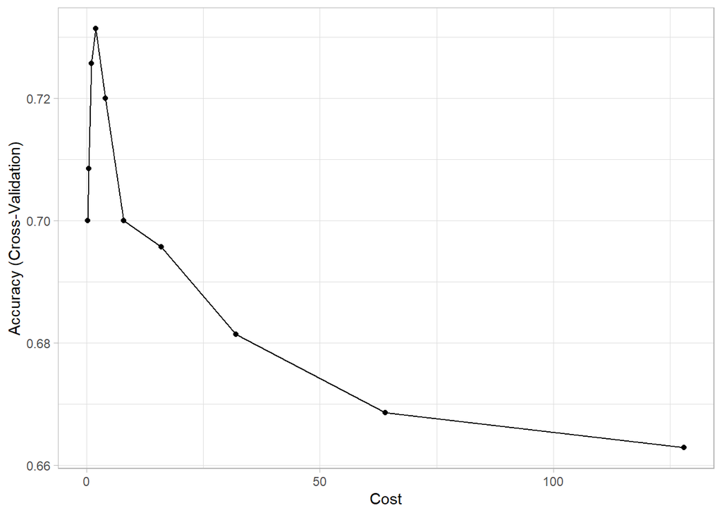

```r
# Tune an SVM with radial basis kernel
set.seed(1)  # for reproducibility
credit_svm <- train(
  default ~ .,
  data = df_train,
  method = "svmRadial",
  preProcess = c("center", "scale"),
  trControl = trainControl(method = "cv", number = 10),
  tuneLength = 10
)
# Plot results
ggplot(credit_svm) + theme_light()
```

```r
summary(credit_svm$bestTune)
```

```
##      sigma               C
##  Min.   :0.01843   Min.   :2
##  1st Qu.:0.01843   1st Qu.:2
##  Median :0.01843   Median :2
##  Mean   :0.01843   Mean   :2
##  3rd Qu.:0.01843   3rd Qu.:2
##  Max.   :0.01843   Max.   :2
```

```r
# Control params for SVM
ctrl <- trainControl(
  method = "cv",
  number = 10,
  classProbs = TRUE,
  summaryFunction = twoClassSummary  # also needed for AUC/ROC
)

# Tune an SVM
set.seed(1)  # for reproducibility
credit_svm_auc <- train(
  default ~ .,
  data = df_train,
  method = "svmRadial",
  preProcess = c("center", "scale"),
  metric = "ROC",  # area under ROC curve (AUC)
  trControl = ctrl,
  tuneLength = 10
)

credit_svm_auc$bestTune
```

```
##        sigma C
## 3 0.01843421 1
```

```r
confusionMatrix(predict(credit_svm_auc,df_test),as.factor(df_test$default))
```

```
## Confusion Matrix and Statistics
##
##           Reference
## Prediction  no yes
##        no  186  54
##        yes  24  36
##
##                Accuracy : 0.74
##                  95% CI : (0.6865, 0.7887)
##     No Information Rate : 0.7
##     P-Value [Acc > NIR] : 0.072279
##
##                   Kappa : 0.3158
##
##  Mcnemar's Test P-Value : 0.001025
##
##             Sensitivity : 0.8857
##             Specificity : 0.4000
##          Pos Pred Value : 0.7750
##          Neg Pred Value : 0.6000
##              Prevalence : 0.7000
##          Detection Rate : 0.6200
##    Detection Prevalence : 0.8000
##       Balanced Accuracy : 0.6429
##
##        'Positive' Class : no
##
```

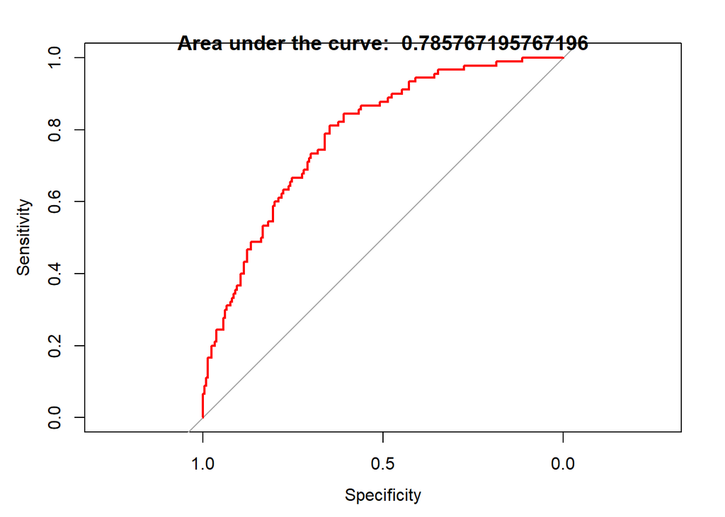

```r
library(pROC)
pred_default_prob <- predict(credit_svm_auc,df_test,type = "prob")
roc_1 <- roc(as.factor(df_test$default), pred_default_prob[,"yes"])
plot(roc_1, col="red", lwd=2)
title(main = paste('Area under the curve: ',auc(roc_1)))
```

## 1.3 Task 3

Read up on section 14.3.2 of Boehmke et al. and the support vector regression code in Chapter 14: Support Vector Machines (koalaverse.github.io) underneath Figure 14.10. *Estimate a 20% test sample of the `Ames dataset` the predicted `Sale_Price.` `Scatterplot` the observed and predicted sales price for the test sample against each other.* Show your code. [5 points]

```r
ames <- make_ames()
# Stratified Random Sampling
amesSplit <- initial_split(ames, breaks=8, prop=0.8, strata="Sale_Price")
ames_train <- training(amesSplit)
ames_test <- testing(amesSplit)
```

```r
library(kernlab)
set.seed(1)
ames_svm <- ksvm(Sale_Price ~ .,data = ames_train,kernel = 'rbfdot',kpar = 'automatic',
                          type = 'eps-svr',epsilon = 0.1)
# ames_svm <- train(
#   Sale_Price ~ .,
#   data = ames_train,
#   method = "svmRadial",
#   preProcess = c("center", "scale"),
#   trControl = trainControl(method = "cv", number = 5),
#   tuneLength = 10
# )
# ggplot(ames_svm) + theme_light()
```

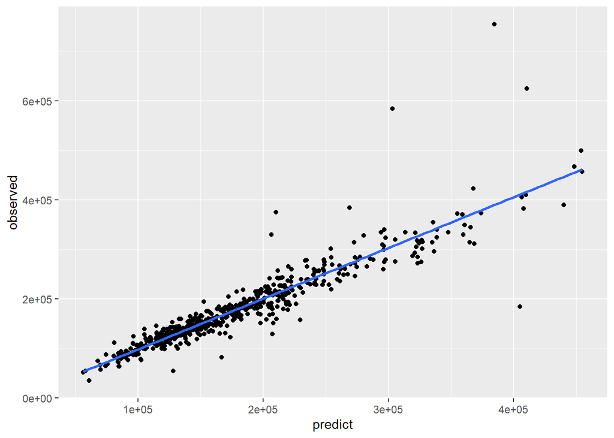

```r
y.pred <- predict(ames_svm,newdata = ames_test)
svm_result <- data.frame(predict = y.pred, observed = ames_test$Sale_Price)
ggplot(svm_result,aes(x=predict, y=observed)) +
  geom_point() +
  geom_smooth(method=lm, se=FALSE, fullrange=TRUE)
```

# 2 Part 2: Neural Networks [4 points]

You will us the code provided to you in the script `Task4&5.R` and answer the following questions

## 2.1 Task4: : Comparison of logistic regression with a one-layer one-neuron network. [2 points]

```r
#install.packages("neuralnet")
RNGversion("3.5.3"); set.seed(12345)
library(neuralnet)
help("neuralnet")

## custom normalization function
normalize <- function(x) { (x - min(x)) / (max(x) - min(x)) }

## create the custom soft-plus activation function
softplus <- function(x) { log(1 + exp(x)) }

data(Boston, package="MASS")
summary(Boston)
```

```
##       crim                zn             indus            chas
##  Min.   : 0.00632   Min.   :  0.00   Min.   : 0.46   Min.   :0.00000
##  1st Qu.: 0.08205   1st Qu.:  0.00   1st Qu.: 5.19   1st Qu.:0.00000
##  Median : 0.25651   Median :  0.00   Median : 9.69   Median :0.00000
##  Mean   : 3.61352   Mean   : 11.36   Mean   :11.14   Mean   :0.06917
##  3rd Qu.: 3.67708   3rd Qu.: 12.50   3rd Qu.:18.10   3rd Qu.:0.00000
##  Max.   :88.97620   Max.   :100.00   Max.   :27.74   Max.   :1.00000
##       nox               rm             age              dis
##  Min.   :0.3850   Min.   :3.561   Min.   :  2.90   Min.   : 1.130
##  1st Qu.:0.4490   1st Qu.:5.886   1st Qu.: 45.02   1st Qu.: 2.100
##  Median :0.5380   Median :6.208   Median : 77.50   Median : 3.207
##  Mean   :0.5547   Mean   :6.285   Mean   : 68.57   Mean   : 3.795
##  3rd Qu.:0.6240   3rd Qu.:6.623   3rd Qu.: 94.08   3rd Qu.: 5.188
##  Max.   :0.8710   Max.   :8.780   Max.   :100.00   Max.   :12.127
##       rad              tax           ptratio          black
##  Min.   : 1.000   Min.   :187.0   Min.   :12.60   Min.   :  0.32
##  1st Qu.: 4.000   1st Qu.:279.0   1st Qu.:17.40   1st Qu.:375.38
##  Median : 5.000   Median :330.0   Median :19.05   Median :391.44
##  Mean   : 9.549   Mean   :408.2   Mean   :18.46   Mean   :356.67
##  3rd Qu.:24.000   3rd Qu.:666.0   3rd Qu.:20.20   3rd Qu.:396.23
##  Max.   :24.000   Max.   :711.0   Max.   :22.00   Max.   :396.90
##      lstat            medv
##  Min.   : 1.73   Min.   : 5.00
##  1st Qu.: 6.95   1st Qu.:17.02
##  Median :11.36   Median :21.20
##  Mean   :12.65   Mean   :22.53
##  3rd Qu.:16.95   3rd Qu.:25.00
##  Max.   :37.97   Max.   :50.00
```

```r
# ## Exclude home values that were trunctated at $50k
# sel <- Boston$medv == 50
# table(sel)
# Boston <- Boston[!sel,]

## apply normalization to entire data frame
nBoston <- as.data.frame(lapply(Boston, normalize))

##
## Investigation of model structure without split into training and test sample
##

## Logistic Regression possible here because y transformed into (0,1).
## This is just for demonstration purposes. It should NOT be done in practice!
## Significance not relevant here
logit01 <- glm(medv ~ ., data = nBoston, family=binomial())
summary(logit01)
```

```
##
## Call:
## glm(formula = medv ~ ., family = binomial(), data = nBoston)
##
## Deviance Residuals:
##      Min        1Q    Median        3Q       Max
## -0.82579  -0.12751  -0.02403   0.09725   1.27108
##
## Coefficients:
##             Estimate Std. Error z value Pr(>|z|)
## (Intercept) -0.22178    1.14318  -0.194   0.8462
## crim        -1.87483    2.01400  -0.931   0.3519
## zn           0.37159    0.62063   0.599   0.5494
## indus        0.16414    0.75829   0.216   0.8286
## chas         0.26193    0.39221   0.668   0.5042
## nox         -0.78077    0.88449  -0.883   0.3774
## rm           2.02738    1.06449   1.905   0.0568 .
## age          0.08565    0.59182   0.145   0.8849
## dis         -1.42016    1.00069  -1.419   0.1558
## rad          0.80526    0.74593   1.080   0.2803
## tax         -0.68853    0.92409  -0.745   0.4562
## ptratio     -0.83012    0.56282  -1.475   0.1402
## black        0.40861    0.57150   0.715   0.4746
## lstat       -2.35014    0.95998  -2.448   0.0144 *
## ---
## Signif. codes:  0 '***' 0.001 '**' 0.01 '*' 0.05 '.' 0.1 ' ' 1
##
## (Dispersion parameter for binomial family taken to be 1)
##
##     Null deviance: 99.698  on 505  degrees of freedom
## Residual deviance: 29.045  on 492  degrees of freedom
## AIC: 454.33
##
## Number of Fisher Scoring iterations: 5
```

```r
car::vif(logit01)
```

```
##     crim       zn    indus     chas      nox       rm      age      dis
## 1.940429 2.305217 3.617594 1.071122 4.306924 1.754560 3.090468 3.824120
##      rad      tax  ptratio    black    lstat
## 7.404237 8.343842 1.694211 1.316845 2.683463
```

```r
logit01.pred <- predict(logit01, type="response")
cor(logit01.pred, nBoston$medv)
```

```
## [1] 0.8776418
```

```r
## Neural Network Model
nnet01 <- neuralnet(medv ~ ., data = nBoston, act.fct="logistic",
                    linear.output = TRUE, stepmax=10000, hidden = c(1))

## plot the network with weights and bias terms
plot(nnet01)
```

[output not shown]

```r
##
## Compare logistic parameters to NN weights.
## Note intercept and bias coefficients are different.
##
# str(nnet01)
data.frame(Logistic=coef(logit01), NeuroNet=nnet01$weights[[1]][[1]])
```

```
##                Logistic    NeuroNet
## (Intercept) -0.22178214 -1.79497800
## crim        -1.87482934 -2.39785320
## zn           0.37158835  0.16138414
## indus        0.16414284  0.16942573
## chas         0.26193115  0.09578579
## nox         -0.78076876 -0.63305375
## rm           2.02738148  1.27904758
## age          0.08564518  0.11997188
## dis         -1.42015674 -1.01593593
## rad          0.80526358  0.85981254
## tax         -0.68853011 -0.51925002
## ptratio     -0.83011882 -0.65575337
## black        0.40860606  0.51724952
## lstat       -2.35013788 -3.10735350
```